# pipeline

Ther most convenient way to use VAME is through the VAME pipeline. The pipeline class automates the processes of:

- loading the data
- preprocessing the data
- creating and training the VAME model
- validating the VAME model
- segmenting the behavior into motifs
- clustering the motifs into communities
- visualizing the results

Let's start by importing the necessary libraries:

```python
%load_ext autoreload
%autoreload 2
```

```python
import pprint
from vame.pipeline import VAMEPipeline
from vame.util.sample_data import download_sample_data
```

```
2024-12-31 10:48:29.956 INFO  --- [MainThread] vame.model.rnn_vae : 25 : Using CUDA
2024-12-31 10:48:29.957 INFO  --- [MainThread] vame.model.rnn_vae : 26 : GPU active: True
2024-12-31 10:48:29.994 INFO  --- [MainThread] vame.model.rnn_vae : 27 : GPU used: NVIDIA GeForce RTX 2060
Downloading data from 'https://gin.g-node.org/neuroinformatics/movement-test-data/raw/master/metadata.yaml' to file '/home/luiz/.movement/data/temp_metadata.yaml'.
SHA256 hash of downloaded file: 01340c169837a135995ebf6698c3add72e3b4bef5e0bf64150103f2b0e45dd25
Use this value as the 'known_hash' argument of 'pooch.retrieve' to ensure that the file hasn't changed if it is downloaded again in the future.
2024-12-31 10:48:34.330 DEBUG --- [MainThread] movement.sample_data : 66 : Successfully downloaded sample metadata file metadata.yaml from https://gin.g-node.org/neuroinformatics/movement-test-data/raw/master to /home/luiz/.movement/data
```

## Input data

To quickly try VAME, you can download sample data and use it as input. If you want to work with your own data, all you need to do is to provide the paths to the video and pose estimation files as lists of strings.

```python
# You can run VAME with data from different sources:
# "DeepLabCut", "SLEAP" or "LightningPose"
source_software = "DeepLabCut"

# Download sample data
ps = download_sample_data(source_software)
videos = [ps["video"]]
poses_estimations = [ps["poses"]]

pprint.pp(videos)
pprint.pp(poses_estimations)
```

```
['/home/luiz/.movement/data/videos/single-mouse_EPM_video.mp4']
['/home/luiz/.movement/data/poses/DLC_single-mouse_EPM.predictions.csv']
```

## Instantiate the VAME pipeline

Now it's time to instantiate the VAME pipeline. Select your working directory, name of your project and extra configuration arguments. The extra configuration arguments are optional and can be used to customize the VAME pipeline.

```python
# Set up your working directory and project name
working_directory = '.'
project_name = 'pipeline_example'

# Customize the configuration for the project
config_kwargs = {
    "n_clusters": 15,
    "pose_confidence": 0.9,
    "max_epochs": 100,
}

# Instantiate the pipeline
# this will create a VAME project and prepare the data
pipeline = VAMEPipeline(
    working_directory=working_directory,
    project_name=project_name,
    videos=videos,
    poses_estimations=poses_estimations,
    source_software=source_software,
    config_kwargs=config_kwargs,
)
```

```
2024-12-31 10:48:34.443 INFO  --- [MainThread] vame.initialize_project.new : 109 : Created "/mnt/shared_storage/Github/VAME/examples/pipeline_example/data"
2024-12-31 10:48:34.444 INFO  --- [MainThread] vame.initialize_project.new : 109 : Created "/mnt/shared_storage/Github/VAME/examples/pipeline_example/data/raw"
2024-12-31 10:48:34.445 INFO  --- [MainThread] vame.initialize_project.new : 109 : Created "/mnt/shared_storage/Github/VAME/examples/pipeline_example/data/processed"
2024-12-31 10:48:34.446 INFO  --- [MainThread] vame.initialize_project.new : 109 : Created "/mnt/shared_storage/Github/VAME/examples/pipeline_example/results"
2024-12-31 10:48:34.447 INFO  --- [MainThread] vame.initialize_project.new : 109 : Created "/mnt/shared_storage/Github/VAME/examples/pipeline_example/model"
2024-12-31 10:48:34.448 INFO  --- [MainThread] vame.initialize_project.new : 109 : Created "/mnt/shared_storage/Github/VAME/examples/pipeline_example/model/pretrained_model"
2024-12-31 10:48:34.448 INFO  --- [MainThread] vame.initialize_project.new : 109 : Created "/mnt/shared_storage/Github/VAME/examples/pipeline_example/model/evaluate"
2024-12-31 10:48:34.449 INFO  --- [MainThread] vame.initialize_project.new : 181 : Copying / linking the video files...

2024-12-31 10:48:34.450 INFO  --- [MainThread] vame.initialize_project.new : 188 : Creating symbolic link from /home/luiz/.movement/data/videos/single-mouse_EPM_video.mp4 to /mnt/shared_storage/Github/VAME/examples/pipeline_example/data/raw/single-mouse_EPM_video.mp4
2024-12-31 10:48:34.466 INFO  --- [MainThread] vame.initialize_project.new : 194 : Copying pose estimation raw data...

2024-12-31 10:48:34.574 DEBUG --- [MainThread] movement.io.load_poses : 394 : Loaded poses from /home/luiz/.movement/data/poses/DLC_single-mouse_EPM.predictions.csv into a DataFrame.
2024-12-31 10:48:34.576 INFO  --- [MainThread] movement.io.load_poses : 401 : Loaded pose tracks from /home/luiz/.movement/data/poses/DLC_single-mouse_EPM.predictions.csv:
2024-12-31 10:48:34.578 INFO  --- [MainThread] movement.io.load_poses : 402 : <xarray.Dataset> Size: 4MB
Dimensions:      (time: 18485, individuals: 1, keypoints: 8, space: 2)
Coordinates:
  * time         (time) float64 148kB 0.0 0.03333 0.06667 ... 616.1 616.1 616.1
  * individuals  (individuals) <U12 48B 'individual_0'
  * keypoints    (keypoints) <U13 416B 'snout' 'left_ear' ... 'tail_end'
  * space        (space) <U1 8B 'x' 'y'
Data variables:
    position     (time, individuals, keypoints, space) float64 2MB 508.4 ... ...
    confidence   (time, individuals, keypoints) float64 1MB 0.0002829 ... 0.9978
Attributes:
    fps:              30.0
    time_unit:        seconds
    source_software:  DeepLabCut
    source_file:      /home/luiz/.movement/data/poses/DLC_single-mouse_EPM.pr...
    ds_type:          poses
2024-12-31 10:48:34.681 INFO  --- [MainThread] vame.initialize_project.new : 245 : A VAME project has been created at /mnt/shared_storage/Github/VAME/examples/pipeline_example
```

Before running the pipeline, you can check the input datasets:

```python
ds = pipeline.get_raw_datasets()
ds
```

```
<xarray.Dataset> Size: 4MB
Dimensions:      (session: 1, time: 18485, individuals: 1, keypoints: 8,
                  space: 2)
Coordinates:
  * session      (session) object 8B 'single-mouse_EPM_video'
  * time         (time) float64 148kB 0.0 0.03333 0.06667 ... 616.1 616.1 616.1
  * keypoints    (keypoints) object 64B 'snout' 'left_ear' ... 'tail_end'
  * space        (space) object 16B 'x' 'y'
  * individuals  (individuals) object 8B 'individual_0'
Data variables:
    position     (session, time, individuals, keypoints, space) float64 2MB 5...
    confidence   (session, time, individuals, keypoints) float64 1MB 0.000282...
Attributes:
    fps:              30.0
    time_unit:        seconds
    source_software:  DeepLabCut
    source_file:      /home/luiz/.movement/data/poses/DLC_single-mouse_EPM.pr...
    ds_type:          poses
    video_path:       /home/luiz/.movement/data/videos/single-mouse_EPM_video...
```

## Run the pipeline

Now you can run the pipeline. At this point, you should pass the names of the pose estimation keypoints to be used for egocentric alignment.

Note: The pipeline will take some time to run, depending on the size of the dataset, number of epochs, and if you are using a GPU or not.

```python
preprocessing_kwargs = {
    "centered_reference_keypoint": "snout",
    "orientation_reference_keypoint": "tailbase",
}
pipeline.run_pipeline(preprocessing_kwargs=preprocessing_kwargs)
```

```
2024-12-31 10:48:34.761 INFO  --- [MainThread] vame.preprocessing.preprocessing : 38 : Cleaning low confidence data points...
2024-12-31 10:48:34.762 INFO  --- [MainThread] vame.preprocessing.cleaning : 39 : Cleaning low confidence data points. Confidence threshold: 0.9
2024-12-31 10:48:34.762 INFO  --- [MainThread] vame.preprocessing.cleaning : 42 : Session: single-mouse_EPM_video
2024-12-31 10:48:34.832 INFO  --- [MainThread] vame.preprocessing.preprocessing : 46 : Egocentrically aligning and centering...
2024-12-31 10:48:34.832 INFO  --- [MainThread] vame.preprocessing.alignment : 36 : Egocentric alignment with references: snout and tailbase
2024-12-31 10:48:34.833 INFO  --- [MainThread] vame.preprocessing.alignment : 43 : Session: single-mouse_EPM_video
2024-12-31 10:48:35.92 INFO  --- [MainThread] vame.preprocessing.preprocessing : 56 : Cleaning outliers...
2024-12-31 10:48:35.93 INFO  --- [MainThread] vame.preprocessing.cleaning : 114 : Cleaning outliers with Z-score transformation and IQR cutoff.
2024-12-31 10:48:35.94 INFO  --- [MainThread] vame.preprocessing.cleaning : 119 : Session: single-mouse_EPM_video
2024-12-31 10:48:35.204 INFO  --- [MainThread] vame.preprocessing.preprocessing : 64 : Applying Savitzky-Golay filter...
2024-12-31 10:48:35.205 INFO  --- [MainThread] vame.preprocessing.filter : 34 : Applying Savitzky-Golay filter...
2024-12-31 10:48:35.206 INFO  --- [MainThread] vame.preprocessing.filter : 41 : Session: single-mouse_EPM_video
2024-12-31 10:48:35.336 INFO  --- [MainThread] vame.model.create_training : 286 : Creating training dataset...
2024-12-31 10:48:35.337 INFO  --- [MainThread] vame.model.create_training : 289 : Creating trainset from the vame.egocentrical_alignment() output
2024-12-31 10:48:35.392 INFO  --- [MainThread] vame.model.create_training : 71 : Lenght of train data: 16637
2024-12-31 10:48:35.393 INFO  --- [MainThread] vame.model.create_training : 72 : Lenght of test data: 1848
2024-12-31 10:48:35.395 INFO  --- [MainThread] vame.model.create_training : 307 : A training and test set has been created. Next step: vame.train_model()
2024-12-31 10:48:35.399 INFO  --- [MainThread] vame.model.rnn_vae : 525 : Train Variational Autoencoder - model name: VAME

2024-12-31 10:48:35.401 INFO  --- [MainThread] vame.model.rnn_vae : 534 : Using CUDA
2024-12-31 10:48:35.402 INFO  --- [MainThread] vame.model.rnn_vae : 535 : GPU active: True
2024-12-31 10:48:35.402 INFO  --- [MainThread] vame.model.rnn_vae : 536 : GPU used: NVIDIA GeForce RTX 2060
2024-12-31 10:48:35.403 INFO  --- [MainThread] vame.model.rnn_vae : 584 : Latent Dimensions: 30, Time window: 30, Batch Size: 256, Beta: 1, lr: 0.0005

2024-12-31 10:48:35.534 INFO  --- [MainThread] vame.model.dataloader : 52 : Compute mean and std for temporal dataset.
2024-12-31 10:48:35.536 INFO  --- [MainThread] vame.model.dataloader : 62 : Initialize train data. Datapoints 16637
2024-12-31 10:48:35.539 INFO  --- [MainThread] vame.model.dataloader : 64 : Initialize test data. Datapoints 1848
2024-12-31 10:48:36.86 INFO  --- [MainThread] vame.model.rnn_vae : 696 : Scheduler step size: 100, Scheduler gamma: 0.20

2024-12-31 10:48:36.87 INFO  --- [MainThread] vame.model.rnn_vae : 712 : Start training...
2024-12-31 10:48:40.713 INFO  --- [MainThread] vame.model.rnn_vae : 462 : Test loss: 23826.222, MSE-Loss: 23826.222, KL-Loss: 0.000, Kmeans-Loss: 0.000
2024-12-31 10:48:40.719 INFO  --- [MainThread] vame.model.rnn_vae : 879 :

2024-12-31 10:48:45.40 INFO  --- [MainThread] vame.model.rnn_vae : 462 : Test loss: 20163.279, MSE-Loss: 20163.279, KL-Loss: 0.000, Kmeans-Loss: 0.000
2024-12-31 10:48:45.44 INFO  --- [MainThread] vame.model.rnn_vae : 879 :

2024-12-31 10:48:49.398 INFO  --- [MainThread] vame.model.rnn_vae : 462 : Test loss: 18097.325, MSE-Loss: 18095.524, KL-Loss: 1.134, Kmeans-Loss: 0.667
2024-12-31 10:48:49.402 INFO  --- [MainThread] vame.model.rnn_vae : 879 :

2024-12-31 10:48:53.775 INFO  --- [MainThread] vame.model.rnn_vae : 462 : Test loss: 15145.988, MSE-Loss: 15141.998, KL-Loss: 2.533, Kmeans-Loss: 1.457
```

[output cut: 292 more lines]

```
2024-12-31 10:57:56.816 INFO  --- [MainThread] vame.analysis.pose_segmentation : 355 : GPU active: True
2024-12-31 10:57:56.816 INFO  --- [MainThread] vame.analysis.pose_segmentation : 356 : GPU used: NVIDIA GeForce RTX 2060
2024-12-31 10:57:56.817 INFO  --- [MainThread] vame.util.model_util : 40 : Loading model...
2024-12-31 10:57:56.865 INFO  --- [MainThread] vame.analysis.pose_segmentation : 68 : Embedding of latent vector for file single-mouse_EPM_video
2024-12-31 10:58:17.806 INFO  --- [MainThread] vame.analysis.pose_segmentation : 392 : Apply the same segmentation of latent vectors for all sessions, 15 clusters
2024-12-31 10:58:17.807 INFO  --- [MainThread] vame.analysis.pose_segmentation : 164 : Using kmeans as segmentation algorithm!
2024-12-31 10:58:18.878 INFO  --- [MainThread] vame.analysis.pose_segmentation : 197 : Getting motif usage for single-mouse_EPM_video
2024-12-31 10:58:18.879 INFO  --- [MainThread] vame.analysis.pose_segmentation : 473 : /mnt/shared_storage/Github/VAME/examples/pipeline_example/results/single-mouse_EPM_video/VAME/kmeans-15/
2024-12-31 10:58:18.896 INFO  --- [MainThread] vame.analysis.pose_segmentation : 538 : You succesfully extracted motifs with VAME! From here, you can proceed running vame.motif_videos()
2024-12-31 10:58:18.904 INFO  --- [MainThread] vame.analysis.community_analysis : 198 : Zero motifs: []
2024-12-31 10:58:19.160 INFO  --- [MainThread] vame.analysis.community_analysis : 378 : Communities bag:
2024-12-31 10:58:19.161 INFO  --- [MainThread] vame.analysis.community_analysis : 380 : Community 0: [8]
2024-12-31 10:58:19.162 INFO  --- [MainThread] vame.analysis.community_analysis : 380 : Community 1: [10, 9, 7]
2024-12-31 10:58:19.162 INFO  --- [MainThread] vame.analysis.community_analysis : 380 : Community 2: [0, 3, 2, 14, 13]
2024-12-31 10:58:19.163 INFO  --- [MainThread] vame.analysis.community_analysis : 380 : Community 3: [5, 6, 11, 4, 12, 1]
```

## Visualize the results

After running the pipeline, you can visualize the results:

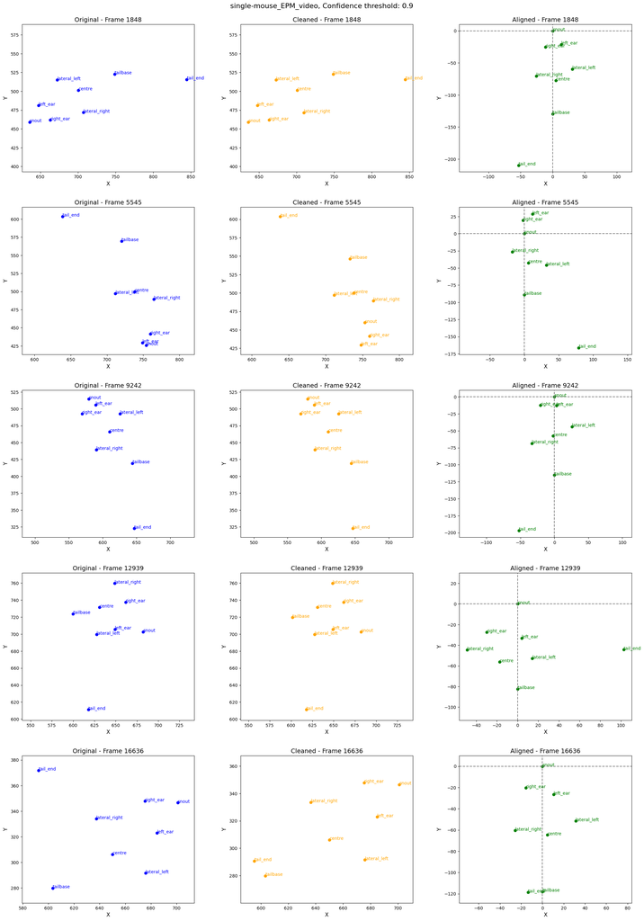

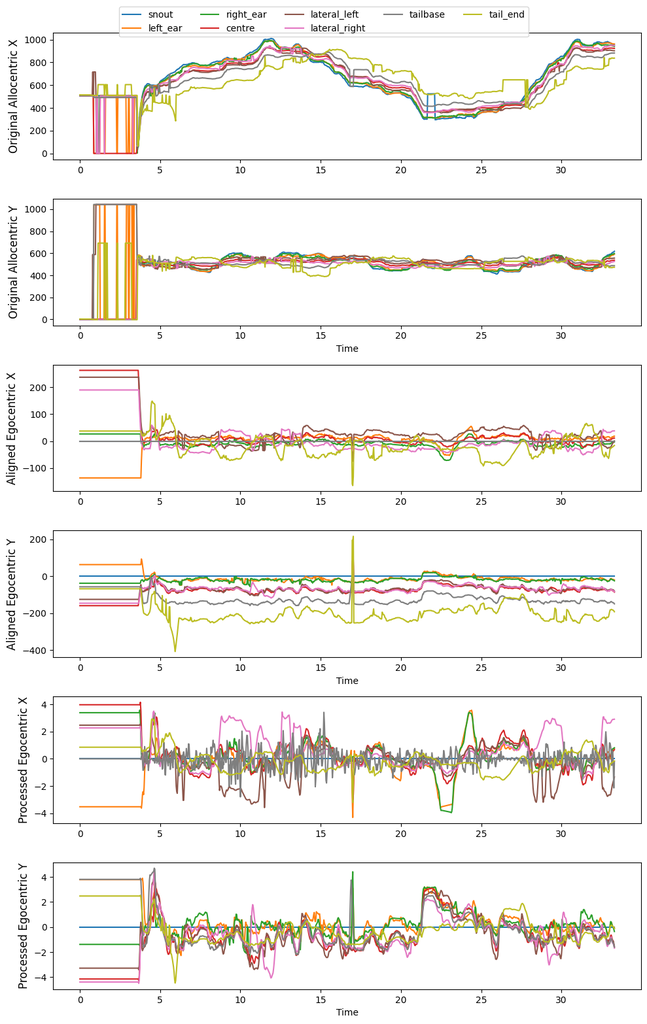

```python
pipeline.visualize_preprocessing(
    show_figure=True,
    save_to_file=False,
)
```

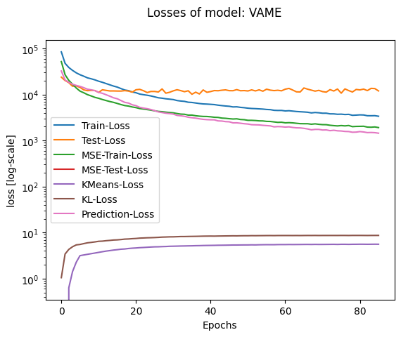

```python
pipeline.visualize_model_losses(
    show_figure=True,
    save_to_file=False,
)
```

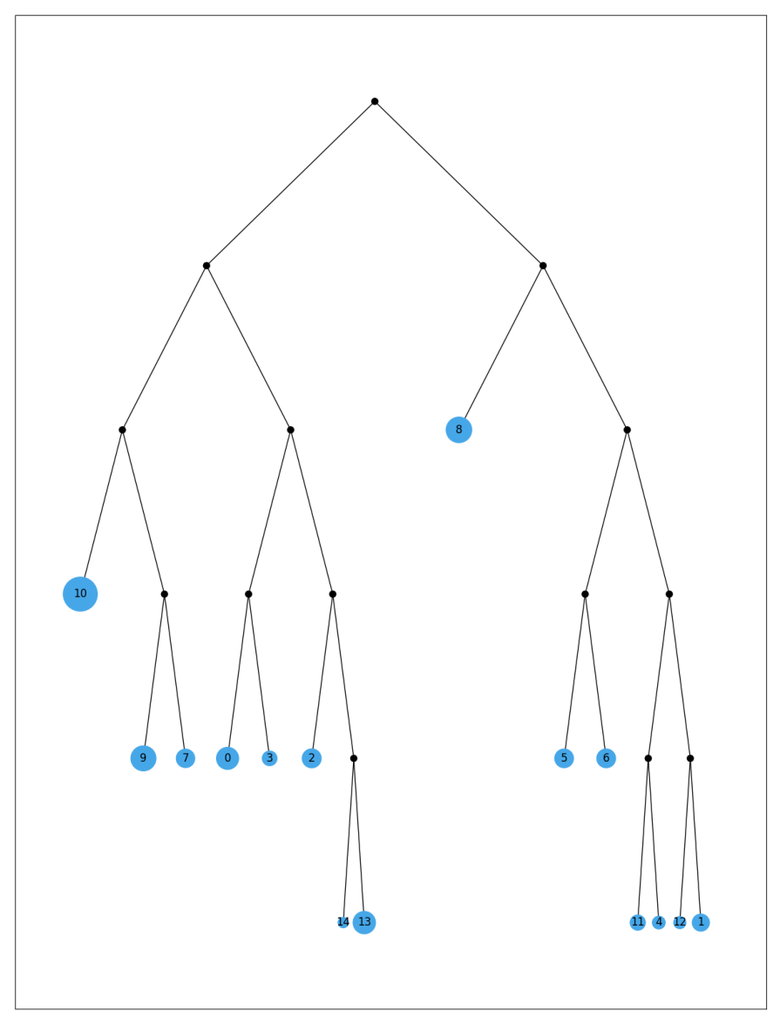

```python
pipeline.visualize_motif_tree(segmentation_algorithm="hmm")
```

```
2024-12-31 10:58:22.158 INFO  --- [MainThread] vame.visualization.umap : 301 : Compute embedding for session single-mouse_EPM_video
2024-12-31 10:58:22.159 INFO  --- [MainThread] vame.visualization.umap : 52 : UMAP calculation for session single-mouse_EPM_video
2024-12-31 10:58:22.161 INFO  --- [MainThread] vame.visualization.umap : 65 : Embedding 18455 data points...
```

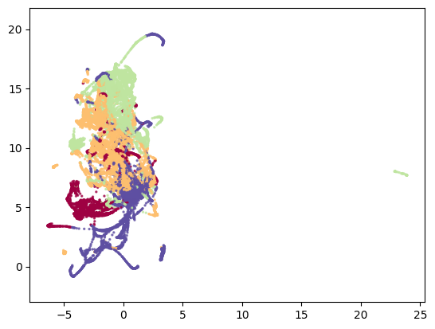

```python
pipeline.visualize_umap(
    label="community",
    segmentation_algorithm="hmm",
    show_figure=True,
)
```

## Produce the pipeline report

```
2024-12-31 10:59:13.486 INFO  --- [MainThread] vame.util.report : 79 : Cohort communities:
2024-12-31 10:59:13.486 INFO  --- [MainThread] vame.util.report : 81 : Community 0: 2210 counts
2024-12-31 10:59:13.487 INFO  --- [MainThread] vame.util.report : 83 :     Motif 8: 2210 counts
2024-12-31 10:59:13.488 INFO  --- [MainThread] vame.util.report : 81 : Community 1: 7244 counts
2024-12-31 10:59:13.489 INFO  --- [MainThread] vame.util.report : 83 :     Motif 10: 4139 counts
2024-12-31 10:59:13.489 INFO  --- [MainThread] vame.util.report : 83 :     Motif 9: 2101 counts
2024-12-31 10:59:13.490 INFO  --- [MainThread] vame.util.report : 83 :     Motif 7: 1004 counts
2024-12-31 10:59:13.491 INFO  --- [MainThread] vame.util.report : 81 : Community 2: 4907 counts
2024-12-31 10:59:13.491 INFO  --- [MainThread] vame.util.report : 83 :     Motif 0: 1578 counts
2024-12-31 10:59:13.492 INFO  --- [MainThread] vame.util.report : 83 :     Motif 3: 525 counts
2024-12-31 10:59:13.492 INFO  --- [MainThread] vame.util.report : 83 :     Motif 2: 1077 counts
2024-12-31 10:59:13.493 INFO  --- [MainThread] vame.util.report : 83 :     Motif 14: 109 counts
2024-12-31 10:59:13.493 INFO  --- [MainThread] vame.util.report : 83 :     Motif 13: 1619 counts
2024-12-31 10:59:13.494 INFO  --- [MainThread] vame.util.report : 81 : Community 3: 4094 counts
2024-12-31 10:59:13.494 INFO  --- [MainThread] vame.util.report : 83 :     Motif 5: 1044 counts
2024-12-31 10:59:13.495 INFO  --- [MainThread] vame.util.report : 83 :     Motif 6: 1053 counts
2024-12-31 10:59:13.496 INFO  --- [MainThread] vame.util.report : 83 :     Motif 11: 587 counts
2024-12-31 10:59:13.496 INFO  --- [MainThread] vame.util.report : 83 :     Motif 4: 322 counts
2024-12-31 10:59:13.497 INFO  --- [MainThread] vame.util.report : 83 :     Motif 12: 262 counts
2024-12-31 10:59:13.497 INFO  --- [MainThread] vame.util.report : 83 :     Motif 1: 825 counts
2024-12-31 10:59:13.847 INFO  --- [MainThread] vame.util.report : 264 : Saved community / motifs plot to /mnt/shared_storage/Github/VAME/examples/pipeline_example/reports/community_motifs_cohort_VAME_hmm-15.png
2024-12-31 10:59:14.172 INFO  --- [MainThread] vame.util.report : 264 : Saved community / motifs plot to /mnt/shared_storage/Github/VAME/examples/pipeline_example/reports/community_motifs_single-mouse_EPM_video_VAME_hmm-15.png
```

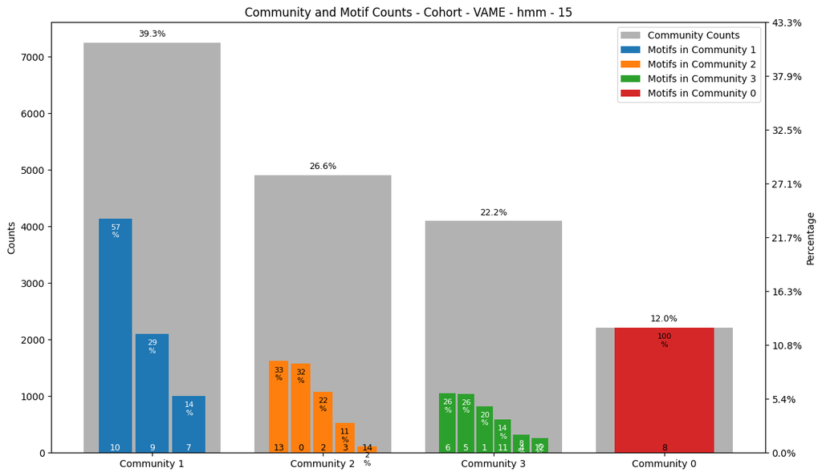

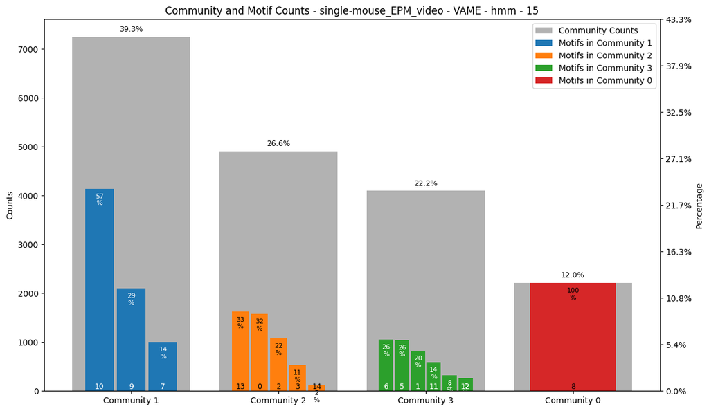

```python
pipeline.report()
```

## Resuming the pipeline

If for some reason you need to stop the pipeline, you can resume it later from any step Example: resuming from community clustering step

```python
pipeline.run_pipeline(from_step=5)
```

```
2024-12-31 11:00:02.8 INFO  --- [MainThread] vame.analysis.community_analysis : 198 : Zero motifs: []
2024-12-31 11:00:02.236 INFO  --- [MainThread] vame.analysis.community_analysis : 378 : Communities bag:
2024-12-31 11:00:02.237 INFO  --- [MainThread] vame.analysis.community_analysis : 380 : Community 0: [8]
2024-12-31 11:00:02.237 INFO  --- [MainThread] vame.analysis.community_analysis : 380 : Community 1: [10, 9, 7]
2024-12-31 11:00:02.237 INFO  --- [MainThread] vame.analysis.community_analysis : 380 : Community 2: [0, 3, 2, 14, 13]
2024-12-31 11:00:02.238 INFO  --- [MainThread] vame.analysis.community_analysis : 380 : Community 3: [5, 6, 11, 4, 12, 1]
```